# QTM 151 - Final Report

Introduction

Formula 1 also known as F1, is the most popular car racing sport in the world. With each competition (known as a grand prix) lasting three days, there is a practice round, a qualifying round to determine the starting positions, and the actual race. The race, held on the last day is 305 kilometers long, with the winner being the driver/car who completes the set number of laps that make up this distance and reaches the finish line the fastest. With each race occurring in a different country with a different route the settings of the races greatly vary. Drivers are ranked by points accumulated from each grand prix, with first place awarding the most points. At the end of each year, the driver with the most points is named the world champion.

The popularity of this sport makes predicting winners either for fun, gambling purposes, or for the participants knowledge, highly coveted information. To increase the accuracy of these predictions multiple factors were compared to the winners of each grand prix and the world championship to determine any correlations. In this analysis, the age and nationality of the drivers, qualifying positions, pit stops, and car constructor standing were all compared to the winning positions to determine if a relationship was present.

Data Description

The data used included the results, drivers, driver standings, constructor, constructor standings,races, qualifying, and pitstops datasets. The results data set was the one that all other data connected back to, as it contains information on the final positions of each driver in the grand prix. It has 25840 observations and 18 columns. The drivers dataset was used to obtain personal information about the drivers and contains 857 entries with 9 columns. The driver standings dataset was used to obtain information about the performance of the drivers in each rave, with 33902 observations and 7 columns. The constructors dataset was used to obtain information about the different car constructor's such as their name and nationality, it has 211 observations with 5 columns. The constructor standings dataset gave information on the performance of cars made by different constructor's and contains 12941 observations with 7 columns. The races dataset gives information about when each grandprix took place and on what circuit. It contains 1102 observations with 18 columns. The qualifying dataset gives information on the drivers qualifying races that occur as a preliminary round for each grand prix. It contains 9575 observations and 9 columns. Finally the pitstops dataset gives information on the number and length of pitstops taken by each participant in the races. It contains 9634 observations and 7 columns.

Import Packages

```python
import pandas as pd
import matplotlib.pyplot as plt
import matplotlib.dates as mdates
from datetime import date, time, datetime
import numpy as np
import statsmodels.api as sm
import statsmodels.formula.api as smf
```

Import Datasets

```python
results = pd.read_csv('data_raw/results.csv')
drivers = pd.read_csv('data_raw/drivers.csv')
races = pd.read_csv('data_raw/races.csv')
qualifying = pd.read_csv('data_raw/qualifying.csv')
driver_standings = pd.read_csv('data_raw/driver_standings.csv')
c_standings = pd.read_csv("data_raw/constructor_standings.csv")
constructors = pd.read_csv('data_raw/constructors.csv')
result = pd.read_csv("data_raw/results.csv")
pitstops = pd.read_csv("data_raw/pit_stops.csv")
```

Count Rows/Columns

```python
print(results.shape, races.shape, drivers.shape, driver_standings.shape, c_standings.shape, pitstops.shape, constructors.shape)
```

[output not shown]

Merging & Calculation Procedures

Columns that identified races, drivers, constructors and their positions were selected from the results dataset. Columns that we hypothesized could relate to the final position of drivers were selected and merged using the pd.merge function from pandas into the results dataset. All datasets used were linked by either raceId, driverId, or constructorIs. Any time a merged column had the same name as an existing column in the results dataset, the columns were renamed. For pitstops, the total number of pitstops was first calculated before it was merged with constructor name, race year, and final finishing time from results. For pits stops the average number of stops, time, stop length for each constructor of each race using aggregate statistics. The year, raceId, and name of the constructor are kept in this final dataframe by keeping the first value that fits in this group. The final number of observations of constructor race results with pitstops is 1561. The columns are renamed accordingly as averages.

```python
results = results[['raceId', 'driverId', 'constructorId','positionOrder']]
results = pd.merge(results, drivers[['driverId', 'dob', 'nationality', 'surname']],
                   on = 'driverId',
                   how = 'left')
results = pd.merge(results, races[['raceId', 'date', 'year']],
                                  on = 'raceId',
                                  how = 'left')
results = pd.merge(results, constructors[['constructorId', 'name']],
                                  on = 'constructorId',
                                  how = 'left')
results = pd.merge(results, qualifying[['raceId', 'driverId', 'position']],
                   on=['raceId', 'driverId'])
results = pd.merge(results, driver_standings[['raceId', 'driverId', 'position', 'points']],
                   on=['raceId', 'driverId'])
results = pd.merge(results, c_standings[['raceId', 'points']],
                 on = "raceId",
                 how = "left")

results.rename(columns={'name': 'constructor_name', 'positionOrder': 'actual_position', 'position_x': 'qualifying_position', 'position_y': 'driver_standing', 'points_x': "driver_points", 'points_y':'constructor_points', 'surname':'driver_surname'}, inplace=True)

result["milliseconds"] = result["milliseconds"].replace(["\\N"], [np.nan])
result['milliseconds'] = pd.to_numeric(result['milliseconds'])
results.dtypes
g_one = pitstops.loc[pitstops.groupby(['raceId', 'driverId'], sort= True)['stop'].idxmax()][['raceId', 'driverId', 'stop', 'milliseconds']]
g_one = g_one.rename(columns={'stop':'total_stops', 'milliseconds': 'stop_length'})
sort = pitstops.sort_values(by = ['driverId', 'raceId' ]) # check g_one values for total_stop
g_one = pd.merge(g_one, result[['driverId', 'raceId','constructorId', 'milliseconds']], on=['raceId', 'driverId'], how='left')
g_one = g_one[g_one['milliseconds'].notna()]
g_one = g_one.rename(columns={'milliseconds': 'time'})
g_one = pd.merge(g_one, constructors[['constructorId', 'name']], on='constructorId', how='left')
g_one = pd.merge(g_one, races[['raceId', 'year']], on='raceId', how='left')
g_one = g_one.groupby(['constructorId', 'raceId'], as_index=True).agg({
    'name': 'first',
    'year': 'first',
    'raceId': 'first',
    'total_stops':'mean',
    'time': 'mean',
    'stop_length': 'mean'
})
g_one = g_one.rename(columns={'total_stops': 'avg_num_stops', 'time':'avg_time', 'stop_length':'avg_stop_length', 'name':'Constructor'})
g_one.to_csv("data_final/pitstops_data.csv")

display(results)
```

|  | raceId | driverId | constructorId | actual_position | dob | nationality | driver_surname | date | year | constructor_name | qualifying_position | driver_standing | driver_points | constructor_points |
| --- | --- | --- | --- | --- | --- | --- | --- | --- | --- | --- | --- | --- | --- | --- |
| 0 | 18 | 1 | 1 | 1 | 1985-01-07 | British | Hamilton | 2008-03-16 | 2008 | McLaren | 1 | 1 | 10.0 | 14.0 |
| 1 | 18 | 1 | 1 | 1 | 1985-01-07 | British | Hamilton | 2008-03-16 | 2008 | McLaren | 1 | 1 | 10.0 | 8.0 |
| 2 | 18 | 1 | 1 | 1 | 1985-01-07 | British | Hamilton | 2008-03-16 | 2008 | McLaren | 1 | 1 | 10.0 | 9.0 |
| 3 | 18 | 1 | 1 | 1 | 1985-01-07 | British | Hamilton | 2008-03-16 | 2008 | McLaren | 1 | 1 | 10.0 | 5.0 |
| 4 | 18 | 1 | 1 | 1 | 1985-01-07 | British | Hamilton | 2008-03-16 | 2008 | McLaren | 1 | 1 | 10.0 | 2.0 |
| ... | ... | ... | ... | ... | ... | ... | ... | ... | ... | ... | ... | ... | ... | ... |
| 101380 | 1096 | 4 | 214 | 20 | 1981-07-29 | Spanish | Alonso | 2022-11-20 | 2022 | Alpine F1 Team | 11 | 9 | 81.0 | 35.0 |
| 101381 | 1096 | 4 | 214 | 20 | 1981-07-29 | Spanish | Alonso | 2022-11-20 | 2022 | Alpine F1 Team | 11 | 9 | 81.0 | 55.0 |
| 101382 | 1096 | 4 | 214 | 20 | 1981-07-29 | Spanish | Alonso | 2022-11-20 | 2022 | Alpine F1 Team | 11 | 9 | 81.0 | 8.0 |
| 101383 | 1096 | 4 | 214 | 20 | 1981-07-29 | Spanish | Alonso | 2022-11-20 | 2022 | Alpine F1 Team | 11 | 9 | 81.0 | 159.0 |
| 101384 | 1096 | 4 | 214 | 20 | 1981-07-29 | Spanish | Alonso | 2022-11-20 | 2022 | Alpine F1 Team | 11 | 9 | 81.0 | 759.0 |

101385 rows × 14 columns

Data Cleaning Procedures

Before analyzing the data, we performed some data cleaning steps to ensure the quality and consistency of the dataset. We viewed the variable types of each variable in the dataset to check for any discripancies as these would be indicative of data that needs to be cleaned. For example, columns with dates were formatted to be recognized as dates. Following this, the columns were manipulated, such as finding the age in years of each driver at the time of each race, to obtain a variable of interest. Columns were also cleaned of NA values to prevent any errors with mathematical operations.

```python
results["dob"] = pd.to_datetime(results["dob"], format="%Y-%m-%d")
results["date"] = pd.to_datetime(results["date"], format="%Y-%m-%d")
results["age"] = pd.DatetimeIndex(results["date"]).year-pd.DatetimeIndex(results["dob"]).year
pitstops["time"] = pd.to_datetime(pitstops["time"], format = "%H:%M:%S")
results = results.replace(["\\N"], [np.nan])

print(results.dtypes)
display(results)
```

```
raceId                          int64
driverId                        int64
constructorId                   int64
actual_position                 int64
dob                    datetime64[ns]
nationality                    object
driver_surname                 object
date                   datetime64[ns]
year                            int64
constructor_name               object
qualifying_position             int64
driver_standing                 int64
driver_points                 float64
constructor_points            float64
age                             int64
dtype: object
```

|  | raceId | driverId | constructorId | actual_position | dob | nationality | driver_surname | date | year | constructor_name | qualifying_position | driver_standing | driver_points | constructor_points | age |
| --- | --- | --- | --- | --- | --- | --- | --- | --- | --- | --- | --- | --- | --- | --- | --- |
| 0 | 18 | 1 | 1 | 1 | 1985-01-07 | British | Hamilton | 2008-03-16 | 2008 | McLaren | 1 | 1 | 10.0 | 14.0 | 23 |
| 1 | 18 | 1 | 1 | 1 | 1985-01-07 | British | Hamilton | 2008-03-16 | 2008 | McLaren | 1 | 1 | 10.0 | 8.0 | 23 |
| 2 | 18 | 1 | 1 | 1 | 1985-01-07 | British | Hamilton | 2008-03-16 | 2008 | McLaren | 1 | 1 | 10.0 | 9.0 | 23 |
| 3 | 18 | 1 | 1 | 1 | 1985-01-07 | British | Hamilton | 2008-03-16 | 2008 | McLaren | 1 | 1 | 10.0 | 5.0 | 23 |
| 4 | 18 | 1 | 1 | 1 | 1985-01-07 | British | Hamilton | 2008-03-16 | 2008 | McLaren | 1 | 1 | 10.0 | 2.0 | 23 |
| ... | ... | ... | ... | ... | ... | ... | ... | ... | ... | ... | ... | ... | ... | ... | ... |
| 101380 | 1096 | 4 | 214 | 20 | 1981-07-29 | Spanish | Alonso | 2022-11-20 | 2022 | Alpine F1 Team | 11 | 9 | 81.0 | 35.0 | 41 |
| 101381 | 1096 | 4 | 214 | 20 | 1981-07-29 | Spanish | Alonso | 2022-11-20 | 2022 | Alpine F1 Team | 11 | 9 | 81.0 | 55.0 | 41 |
| 101382 | 1096 | 4 | 214 | 20 | 1981-07-29 | Spanish | Alonso | 2022-11-20 | 2022 | Alpine F1 Team | 11 | 9 | 81.0 | 8.0 | 41 |
| 101383 | 1096 | 4 | 214 | 20 | 1981-07-29 | Spanish | Alonso | 2022-11-20 | 2022 | Alpine F1 Team | 11 | 9 | 81.0 | 159.0 | 41 |
| 101384 | 1096 | 4 | 214 | 20 | 1981-07-29 | Spanish | Alonso | 2022-11-20 | 2022 | Alpine F1 Team | 11 | 9 | 81.0 | 759.0 | 41 |

101385 rows × 15 columns

Main Columns

```python
print(results['actual_position'].describe())
print(results['driver_points'].describe())
print(results['constructor_points'].describe())

pitstops = pd.read_csv("data_final/pitstops_data.csv")
pitstops[['avg_num_stops', 'avg_time', 'avg_stop_length']].describe()
```

```
count    101385.000000
mean         11.221394
std           6.342299
min           1.000000
25%           6.000000
50%          11.000000
75%          16.000000
max          28.000000
Name: actual_position, dtype: float64
count    101385.000000
mean         34.787335
std          58.816272
min           0.000000
25%           1.000000
50%          10.000000
75%          40.000000
max         454.000000
Name: driver_points, dtype: float64
count    101385.000000
mean         69.260857
std         113.719633
min           0.000000
25%           3.000000
50%          22.000000
75%          80.000000
max         765.000000
Name: constructor_points, dtype: float64
```

|  | avg_num_stops | avg_time | avg_stop_length |
| --- | --- | --- | --- |
| count | 1561.000000 | 1.561000e+03 | 1.561000e+03 |
| mean | 2.095131 | 6.037321e+06 | 8.166231e+04 |
| std | 0.952097 | 1.203749e+06 | 2.765936e+05 |
| min | 1.000000 | 4.526665e+06 | 1.397300e+04 |
| 25% | 1.000000 | 5.435111e+06 | 2.191900e+04 |
| 50% | 2.000000 | 5.773158e+06 | 2.363900e+04 |
| 75% | 3.000000 | 6.193374e+06 | 2.630950e+04 |
| max | 6.000000 | 1.472798e+07 | 2.048175e+06 |

Results

To analyze how the qualifying positions relate to the actual positions, we created two visualizations: a hexbin plot and a box plot.

The hexbin plot shows the correlation between qualifying positions and actual race positions. Each hexagon in the plot represents a grouping of data points, with the x-axis showing the qualifying positions and the y-axis showing the actual race positions. The color of the hexagon corresponds to the number of data points within that region, with darker colors indicating higher concentrations of data points. We can observe a general trend that higher qualifying positions (i.e., closer to 1) tend to result in better race positions. However, there is still some variability, indicating that qualifying position is not the sole determinant of race performance.

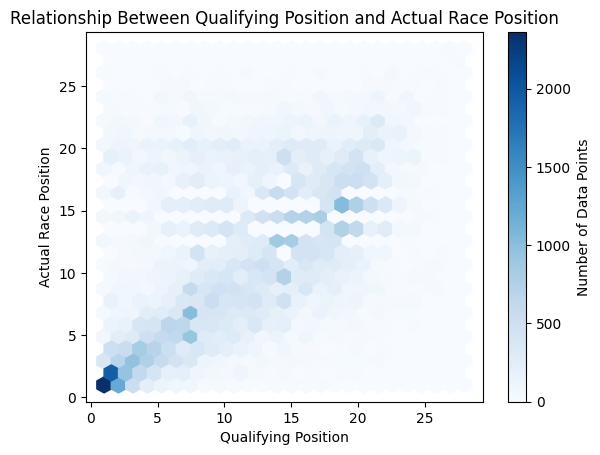

```
Correlation between qualifying positions and actual race positions: 0.5669624498265459
```

```python
plt.hexbin(results['qualifying_position'], results['actual_position'], gridsize=25, cmap='Blues')
plt.xlabel('Qualifying Position')
plt.ylabel('Actual Race Position')
plt.title('Relationship Between Qualifying Position and Actual Race Position')
plt.colorbar().set_label('Number of Data Points')
plt.show()
correlation = results['qualifying_position'].corr(results['actual_position'])
print("Correlation between qualifying positions and actual race positions:", correlation)
correlation_matrix = results.corr()
```

The box plot displays the absolute difference between actual and qualifying positions, grouped by driver standings tiers (low, mid, and high). This visualization helps us understand how the differences between qualifying and actual positions vary across different tiers of drivers. The box plot shows that the variability in the difference between qualifying and actual positions is generally lower for high-tier drivers, indicating that their qualifying performance is more consistent with their race performance.

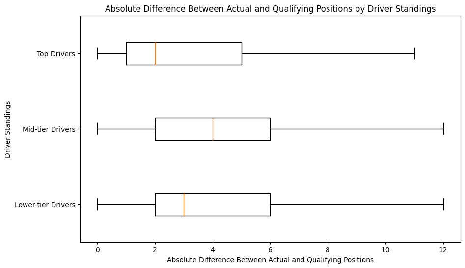

```python
num_groups = 3
group_labels = ['Lower-tier Drivers', 'Mid-tier Drivers', 'Top Drivers']
results['standing_group'] = pd.qcut(-results['driver_standing'], num_groups, labels=group_labels)
fig, ax = plt.subplots(figsize=(10, 6))
box_plot_data = []

for label, group in results.groupby('standing_group'):
    # Calculate the absolute difference between actual and qualifying positions
    box_plot_data.append(abs(group['actual_position'] - group['qualifying_position']))

ax.boxplot(box_plot_data, labels=group_labels, vert=False, showfliers=False)

plt.xlabel('Absolute Difference Between Actual and Qualifying Positions')
plt.ylabel('Driver Standings')
plt.title('Absolute Difference Between Actual and Qualifying Positions by Driver Standings')
plt.show()
```

To analyze the effect of driver biography on the actual positions, we plotted the following:

1. A linear plot of the relation between driver's age and actual position.
2. A stacked bar chart of the distribution of the winner's nationality.
3. A linear plot of the occurance of the top 5 most frequent nationalities of the winner for every year in the data set at the winner's position.

The linear plot shows the relation between the mean age of each driver at each position with the position. An ordinary least squares regression was used to produce a trend line. The result shows that the correlation between the mean age and actual position is weak, suggesting the age of the driver does not affect the position they achieve.

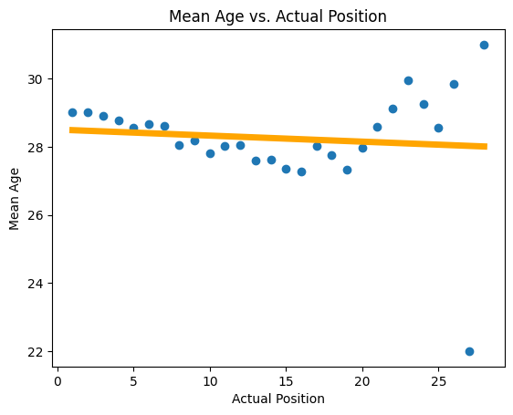

```python
results_age = (results.groupby("actual_position")
               .agg(mean_age = ('age', 'mean')))
results_age.index.name = 'actual_position'
results_age.reset_index(inplace=True)
model   = smf.ols(formula = 'mean_age ~  actual_position', data = results_age)
result = model.fit(cov_type = "HC1")
b_list = result.params
results_age["p_estimated"] = b_list[0] + (b_list[1]*results_age["actual_position"])
results_age
plt.scatter(results_age["actual_position"], y=results_age["mean_age"])
plt.plot(results_age["actual_position"], results_age["p_estimated"], color = "orange", linewidth = '5')
plt.xlabel("Actual Position")
plt.ylabel("Mean Age")
plt.title("Mean Age vs. Actual Position")
plt.show()
```

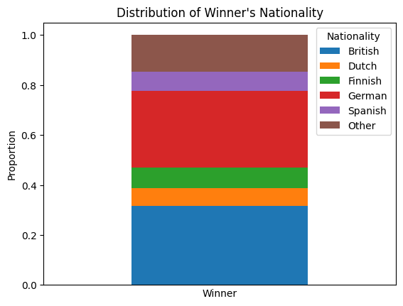

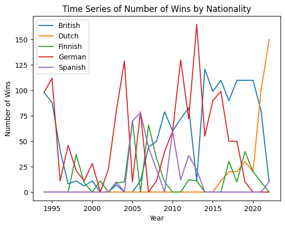

```python
results_nationality = results.groupby(['actual_position', 'nationality']).size()
results_nationality = results_nationality.reset_index()
results_nationality.columns = ['Position', 'Nationality', 'size']
results_nationality["Proportion"] = results_nationality['size'] / results_nationality.groupby('Position')['size'].transform('sum')
results_nationality = results_nationality.drop("size", axis = 1)[results_nationality["Position"] == 1]
results_nationality.loc[len(results_nationality.index)] = [1, "Other", results_nationality[results_nationality.Proportion.lt(0.05)]['Proportion'].sum()]
results_nationality.loc[results_nationality["Proportion"] < 0.05, "Proportion"] = np.nan
results_nationality = pd.pivot(results_nationality, index='Position', columns='Nationality', values='Proportion').reset_index().dropna(axis='columns', how ='all')
results_nationality = results_nationality[['Position', 'British', 'Dutch', 'Finnish', 'German', 'Spanish', 'Other']]
results_nationality_time = results[results["actual_position"] == 1]
results_nationality_time = results_nationality_time.loc[(results_nationality_time['nationality'] == 'British') |
                                                        (results_nationality_time['nationality'] == 'German') |
                                                        (results_nationality_time['nationality'] == 'Spanish') |
                                                        (results_nationality_time['nationality'] == 'Finnish') |
                                                        (results_nationality_time['nationality'] == 'Dutch')]
results_nationality_time = results_nationality_time[["year", "nationality"]]
results_nationality_time = results_nationality_time.groupby(["year", "nationality"]).size()
results_nationality_time = results_nationality_time.reset_index()
results_nationality_time.columns = ["year", "Nationality", "size"]
results_nationality_time = pd.pivot(results_nationality_time, index='year', columns='Nationality', values='size').reset_index()
results_nationality_time = results_nationality_time.fillna(0)

results_nationality.plot(x='Position', kind='bar', stacked=True,
        title='Distribution of Winner\'s Nationality')
plt.xlabel("Winner")
plt.tick_params(bottom = False, labelbottom = False)
plt.ylabel("Proportion")
plt.show()

results_nationality_time.plot(x="year", y=["British", "Dutch", "Finnish", "German", "Spanish"], title='Time Series of Number of Wins by Nationality')
plt.xlabel("Year")
plt.ylabel("Number of Wins")
plt.legend(loc='upper left')
plt.show()
```

To analyze the overall performance of both drivers and constructors over time line plots of their points over the years(seasons) were produced.

| year | driver_surname | sum_points |
| --- | --- | --- |
| 1994 | Adams | 0.0 |
|  | Alboreto | 168.0 |
|  | Alesi | 3066.0 |
|  | Alliot | 0.0 |
|  | Barrichello | 2212.0 |
| ... | ... | ... |
| 2022 | Tsunoda | 2230.0 |
|  | Verstappen | 49600.0 |
|  | Vettel | 3650.0 |
|  | Zhou | 850.0 |
|  | de Vries | 20.0 |

702 rows × 1 columns

[figure not shown]

```python
totalpts_driv = (results.groupby(["year","driver_surname"])
                       .agg(sum_points = ('driver_points','sum')))
display(totalpts_driv)
#find drivers with the most points over the last 5 yrs
totalpts_driv2 = totalpts_driv.query("year>2016")
totalpts_driv2 = (totalpts_driv2.groupby("driver_surname")
                  .agg(sum_points1 = ('sum_points', 'sum')))
top_points = totalpts_driv2.nlargest(n=7, columns = 'sum_points1')
top_drivers = ["Hamilton", "Verstappen", "Bottas", "Vettel", "Leclerc", "Pérez", "Sainz"]
#plot top drivers
totalpts_dsamp = totalpts_driv.query('driver_surname in @top_drivers')
#plot random sample
totalpts_dsamp.unstack().plot()
plt.xticks(rotation=45)
plt.legend(top_drivers, title = "Driver Last Name", loc = 'upper left', fontsize = 7)
plt.title("Top 7 Drivers of the Last 5 Years")
plt.xlabel("Year")
plt.ylabel("Total Points")
plt.xlim(2004, 2022)
plt.show()
```

This line graph is a time series of the number of points accumulated over the year by each constructor. The constructor with the most points at the end of each season is the winner of the Constructor's Championship. With each constructor being allowed to produce cars for up to 2 driver's per years their total number of potential points is higher than that of the drivers. The constructors with the most points over the last 5 years had their points over the years graphed, with some of them dating back to 1994.

| year | constructor_name | sum_points |
| --- | --- | --- |
| 1994 | Benetton | 6864.0 |
|  | Ferrari | 6864.0 |
|  | Footwork | 6864.0 |
|  | Jordan | 6864.0 |
|  | Larrousse | 6864.0 |
| ... | ... | ... |
| 2022 | Haas F1 Team | 53966.0 |
|  | McLaren | 53966.0 |
|  | Mercedes | 53966.0 |
|  | Red Bull | 53966.0 |
|  | Williams | 53966.0 |

317 rows × 1 columns

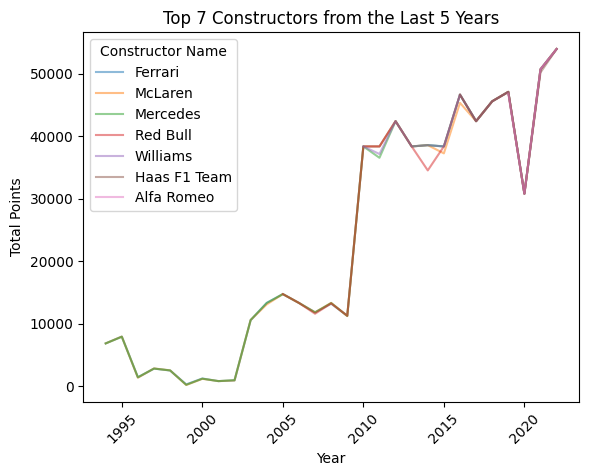

```python
#mean points by constructor id and year
totalpts_con = (results.groupby(["year","constructor_name"])
                       .agg(sum_points = ('constructor_points','sum')))
display(totalpts_con)
#choose random sample to plot
totalpts_con2 = totalpts_con.query("year>2016")
totalpts_con2 = (totalpts_con2.groupby("constructor_name")
                  .agg(sum_points1 = ('sum_points', 'sum')))
top_cpoints = totalpts_con2.nlargest(n=7, columns = 'sum_points1')
top_constructors = ["Ferrari", "McLaren", "Mercedes", "Red Bull", "Williams", "Haas F1 Team", "Alfa Romeo"]
totalpts_csamp = totalpts_con.query('constructor_name in @top_constructors')
#plot
totalpts_csamp.unstack().plot(alpha = 0.5)
plt.xticks(rotation=45)
plt.legend(top_constructors, title = "Constructor Name", loc = 'upper left')
plt.title("Top 7 Constructors from the Last 5 Years")
plt.xlabel("Year")
plt.ylabel("Total Points")
plt.show()
```

To determine if there is a relationship between the number of pitstops and race performance a plot was made comparing pit stops to total race time by constructor.

Comparing the correlation between number of pit stops to finish time, we used an OLS regression to determine the relationship. On average, the finishing time can be estimated by 4.45e5 * number of pits stops + 5.105e6. The positive slope suggests that a greater number of pits stops corresponds to a slower finishing time. The adjusted r squared value is 0.123 indicating that 12.3% of the variation in the finishing time is due to the change in the number of pit stops. The probability of the F-statistic is 9.73e-47, below the alpha value of 0.05 indicating that there is evidence of a relationship between the number of pit stops and the finishing time. From these statistics and the graph where we can see the positive trendline for each constructor, we conclude that there is some effect of the number of pit stops on the finishing time and that constructors who take less pit stops, have a faster finishing time.

```python
import plotly.express as px
import plotly.io as pio
pio.renderers.default = "notebook_connected"

df = g_one
df['inv_stop_length'] = df['avg_stop_length'].apply(lambda x: (1/x)*10000000)
# The inverse stop length creates a larger bubble for a shorter avg. pit stop duration
# Note the multiplication factor allows the min value (the longest pit stop duration to be greater than 1 for graphing purposes)

fig = px.scatter(df, x="avg_num_stops", y="avg_time", animation_frame="Constructor", animation_group="raceId",
           size="inv_stop_length", color="raceId", hover_name="year",
           range_x=[0, 7], range_y=[4000000, 16000000],
           title= "Number Pit Stops vs Overall Time Per Constructor",
           labels={
            "avg_num_stops": "Average Number of Stops",
            "avg_time": "Average Race Time (ms)"
            },
            trendline='ols'
        )
fig.show()

# Fig 2 used to calculate overall trendline + statistical significance (not graphed)
fig2 = px.scatter(df, x="avg_num_stops", y="avg_time", trendline='ols', trendline_scope="overall")
results = px.get_trendline_results(fig2)
results = results.iloc[0]["px_fit_results"].summary()
print(results)
```

[interactive chart not shown]

```
                            OLS Regression Results
==============================================================================
Dep. Variable:                      y   R-squared:                       0.124
Model:                            OLS   Adj. R-squared:                  0.123
Method:                 Least Squares   F-statistic:                     220.4
Date:                Mon, 24 Apr 2023   Prob (F-statistic):           9.73e-47
Time:                        22:14:32   Log-Likelihood:                -23967.
No. Observations:                1561   AIC:                         4.794e+04
Df Residuals:                    1559   BIC:                         4.795e+04
Df Model:                           1
Covariance Type:            nonrobust
==============================================================================
                 coef    std err          t      P>|t|      [0.025      0.975]
------------------------------------------------------------------------------
const       5.105e+06    6.9e+04     74.017      0.000    4.97e+06    5.24e+06
x1           4.45e+05      3e+04     14.847      0.000    3.86e+05    5.04e+05
==============================================================================
Omnibus:                     1141.788   Durbin-Watson:                   1.986
Prob(Omnibus):                  0.000   Jarque-Bera (JB):            20015.194
Skew:                           3.287   Prob(JB):                         0.00
Kurtosis:                      19.264   Cond. No.                         6.46
==============================================================================

Notes:
[1] Standard Errors assume that the covariance matrix of the errors is correctly specified.
```

Discussion

There is a general trend that higher qualifying positions (i.e., closer to 1) tend to result in better race positions. In particular, the darkest hexagons are clustered around the bottom-left corner of the plot, suggesting that drivers who qualify in the first position often secure the victory in the race. However, there is still some variability, indicating that qualifying position is not the sole determinant of race performance. The relationship between driver’s points and therefore performance of the top drivers seems to be somewhat sporadic. With no obvious correlation between the top drivers points over the last 5 years it seems that this data would not be helpful in predicting the winners of the following years. However, the data did show that drivers who have gotten a high number of points in past seasons are likely to continue finishing in the top 10 positions of each grand prix, making it so they accumulate some number of points each season, even if it is not enough to win. The constructors on the other hand, have a lot of overlap for their points within the last 5 years, indicating that the top constructors are relatively stable in their dominance of the sport. Certain aspects of the driver’s biography did seem to be common among the winner. For example, the British and German seemed to have a rather consistent winning streak, and the Dutch have become a rather strong competitor for the top position in recent years. However, the age the driver did not influence the their placement within the top few positions. All the top positions had a mean age of around 30, and the difference in mean age between the first and rest of the top positions was not large. The number of pitstops was found to have a positive correlation with finishing time, indicating that constructors who have the need to take more pit stops on average to not perform as well as those who take fewer. If the average number of pit stops a constructor’s car takes is examined then this can be used to help predict the position that they will get in the grand prix. Overall it was found that some factors such as qualifying position, constructor, nationality, and number of pitstops are correlated with the winners of F1 races and therefore championships. However it was also found that some factors such as age had no correlation. This data can be useful when trying to predict the winners as an outside viewer, or when perfecting a winning strategy as a driver/constructor.